**SYS 6018 | Fall 2019 | University of Virginia**

### Problem 7.1: Bootstrapping

Bootstrap resampling can be used to quantify the uncertainty in a fitted curve.

1. Create a set of functions to generate data from the following distributions:
   $$\begin{align*}
   X &\sim \mathcal{U}(0, 2) \qquad \text{Uniform in $[0,2]$}\\
   Y &= 1 + 2x + 5\sin(5x) + \epsilon \\
   \epsilon &\sim \mathcal{N}(0,\, \sigma=2.5)
   \end{align*}$$

```r
X.Sample <- function(n) runif(n=n, min = 0, max = 2)
f <- function(x) 1 + 2*x + 5*sin(5*x)
e <- function(n) rnorm(n=n, mean = 0, sd = 2.5)
Y.Sample <- function(X, e) f(X) + e
```

2. Simulate $n=100$ realizations from these distributions. Produce a scatterplot and draw the true regression line $f(x) = E[Y \mid X=x]$. Use `set.seed(711)` prior to generating the data.

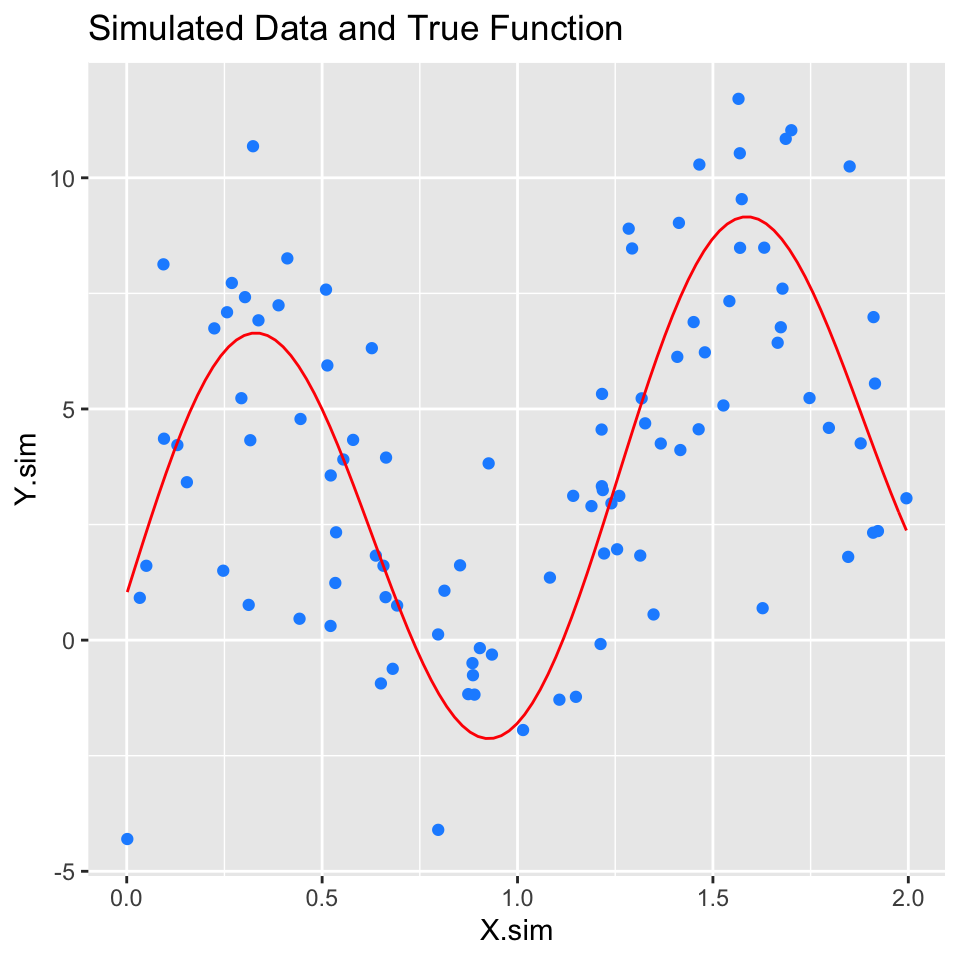

```r
set.seed(711)

X.sim <- X.Sample(100)
e.sim <- e(100)
Y.sim <- Y.Sample(X.sim,e.sim)

Simulation <- data.frame(x = X.sim, y = Y.sim)

ggplot(data.frame(X.sim = X.sim, Y.sim = Y.sim), mapping = aes(x = X.sim, y=Y.sim)) + geom_point(color = "dodgerblue") + stat_function(fun = "f", color = "red") + ggtitle(label = "Simulated Data and True Function")
```

3. Now fit a 5th degree polynomial. Produce a scatterplot and draw the estimated regression line.

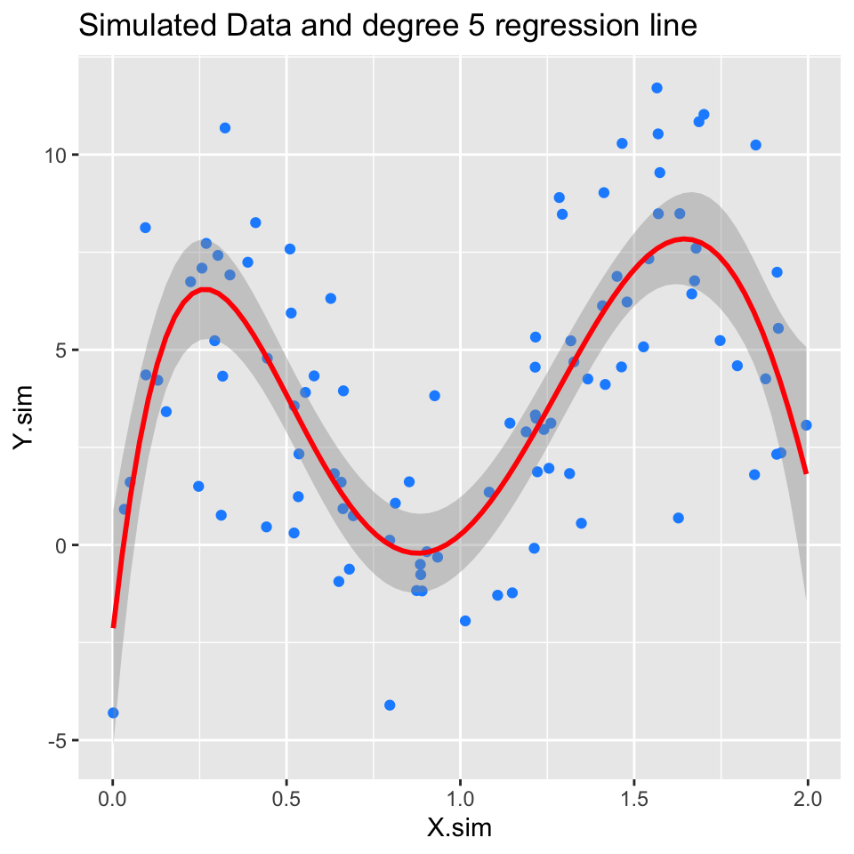

```r
model.d.5 <- lm(Y.sim ~ poly(X.sim, degree = 5))
ggplot(data.frame(X.sim = X.sim, Y.sim = Y.sim), mapping = aes(x = X.sim, y=Y.sim)) + geom_point(color = "dodgerblue") + geom_smooth(method = "lm", data = Simulation, formula = y ~poly(x, degree = 5), color = "red") + ggtitle(label = "Simulated Data and degree 5 regression line")
```

4. Draw $200$ bootstrap samples, fit a 5th degree polynomial to each bootstrap sample, and make predictions at `xseq = seq(0, 2, length=100)`
   - Set the seed (use `set.seed(712)`) so your results are reproducible.
   - Produce a scatterplot and add the $200$ bootstrap curves

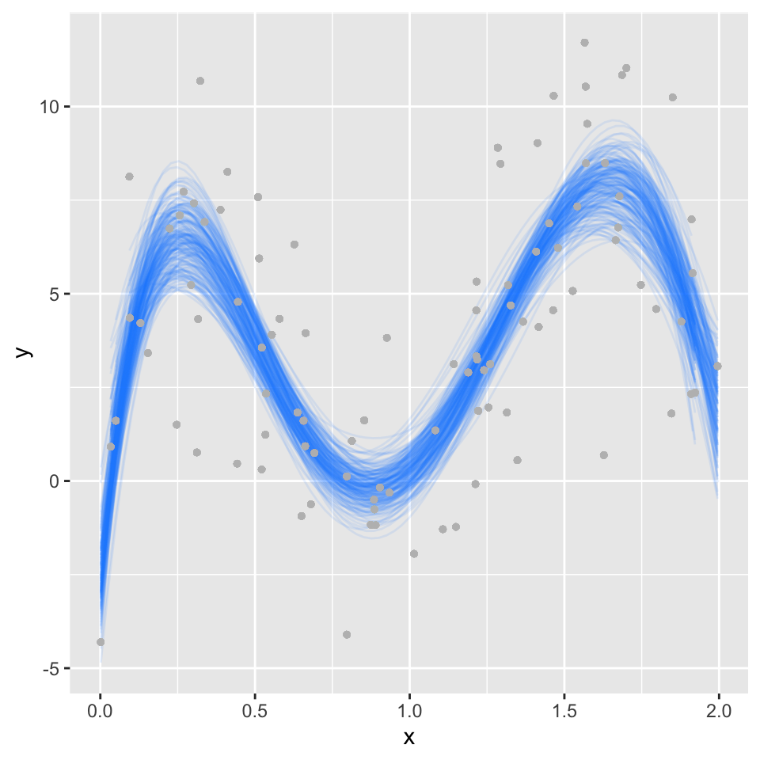

```r
M = 200
X.predict = data.frame(x = seq(0,2,length = 100))
Bootstrap.sim <- data.frame(x = seq(0,2,length = 100), y = Y.Sample(X.predict, e = e.sim))
set.seed(712)
plot <- ggplot(Bootstrap.sim, mapping = aes(x = x, y = y))
lines <- vector()
points <- data.frame()
for(m in 1:M){
  #- sample from empirical distribution
  ind = sample(100, replace=TRUE)    # sample indices with replacement
  data.boot = Simulation[ind,]     # bootstrap sample
  #- fit regression model
  m.boot = lm(y~poly(x,degree=5), data=data.boot) # fit simple OLS

  Bootstrap.sim[,m+2] <- predict(m.boot, X.predict)
  #Bootstrap.sim <- cbind(Bootstrap.sim, predict(m.boot, X.predict), row.names =)
  lines <- append(lines, geom_line(stat = "smooth", data = data.boot, method = "lm", formula = y ~poly(x, degree = 5), se = F, alpha = .1, color = "dodgerblue"))
  points <- rbind(points, data.boot)
}

plot + lines + geom_point(data = points, mapping = aes(x = x, y = y), colour = "grey", alpha = .3, size = 1)
```

5. Calculate the pointwise 95% confidence intervals from the bootstrap samples. That is, for each $x \in xseq$, calculate the upper and lower limits such that only 5% of the curves fall outside the interval at $x$.
   - Remake the plot from part *c*, but add the upper and lower boundaries from the 95% confidence intervals.

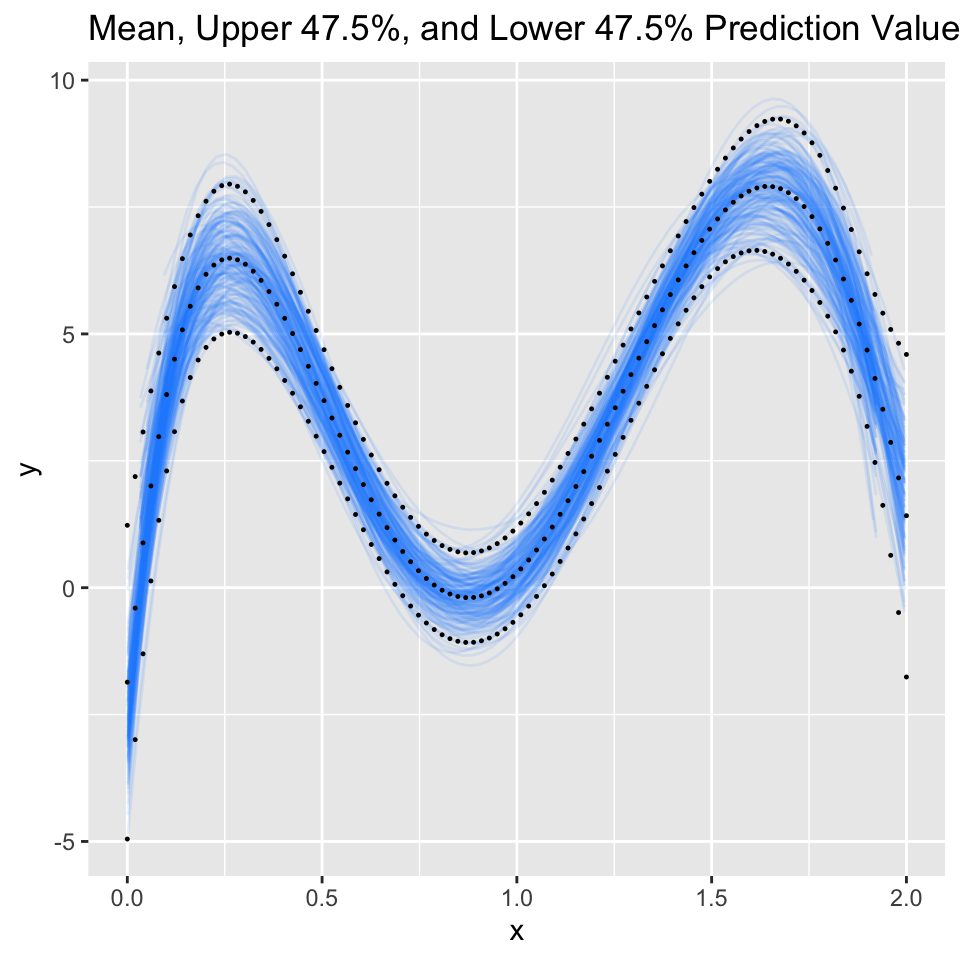

```r
devs <- apply(Bootstrap.sim[,3:202], 1, sd)
means <- apply(Bootstrap.sim[,3:202], 1, mean)
Estimate <- data.frame(x = seq(0,2, length = 100), estimate = means, sd = devs) %>% mutate(lower = estimate - (2*sd), upper = estimate + (2*sd))

plot + lines + geom_point(data = Estimate, mapping = aes(x = x, y = estimate), size = .2) + geom_point(data = Estimate, mapping = aes(x = x, y = upper), size = .2) + geom_point(data = Estimate, mapping = aes(x = x, y = lower), size = .2) + ggtitle(label = "Mean, Upper 47.5%, and Lower 47.5% Prediction Values for X")
```

### Problem 7.2: K-Fold cross-validation with $k$ nearest neighbors

Run 10-fold cross-validation, on the data generated in part 1, to select the optimal $k$ in a k nearest neighbor (kNN) model. Then evaluate how well cross-validation performed by evaluating the performance on a large test set. The steps below will guide you.

1. Use $10$ fold cross-validation to find the value of $k$ (i.e., neighborhood size) that provides the smallest estimated MSE using a kNN model. Search over $k=3,4,\ldots, 50$.
   - Use `set.seed(721)` prior to generating the folds to ensure the results are replicable.
   - Report the optimal $k$, the corresponding estimated MSE, and produce a plot with $k$ on the x-axis and the estimated MSE on the y-axis (optional: add 1-standard error bars).

```r
mse.comparison <- data.frame(K = seq(3,50), mse = rep(0,48))
set.seed(721)
for (k in 3:50) {
start <- 1
mse <- rep(0,10)
for (fold in 1:10) {
end <- start + 9
test <- Simulation[start:end,]
train <- Simulation[-(start:end),]
knn.trial <- knn.reg(train = as.data.frame(train$x), test = as.data.frame(test$x), y = as.data.frame(train$y), k = k)
mse[fold] <- mean((test$y - knn.trial$pred)^2)
start <- end + 1
}
mse.comparison[k-2, 2] <- mean(mse)
}
print("Optimal K and MSE")
```

```
#> [1] "Optimal K and MSE"
```

```r
filter(mse.comparison, mse == min(mse))
```

```
#>    K     mse
#> 1 12 7.59386
```

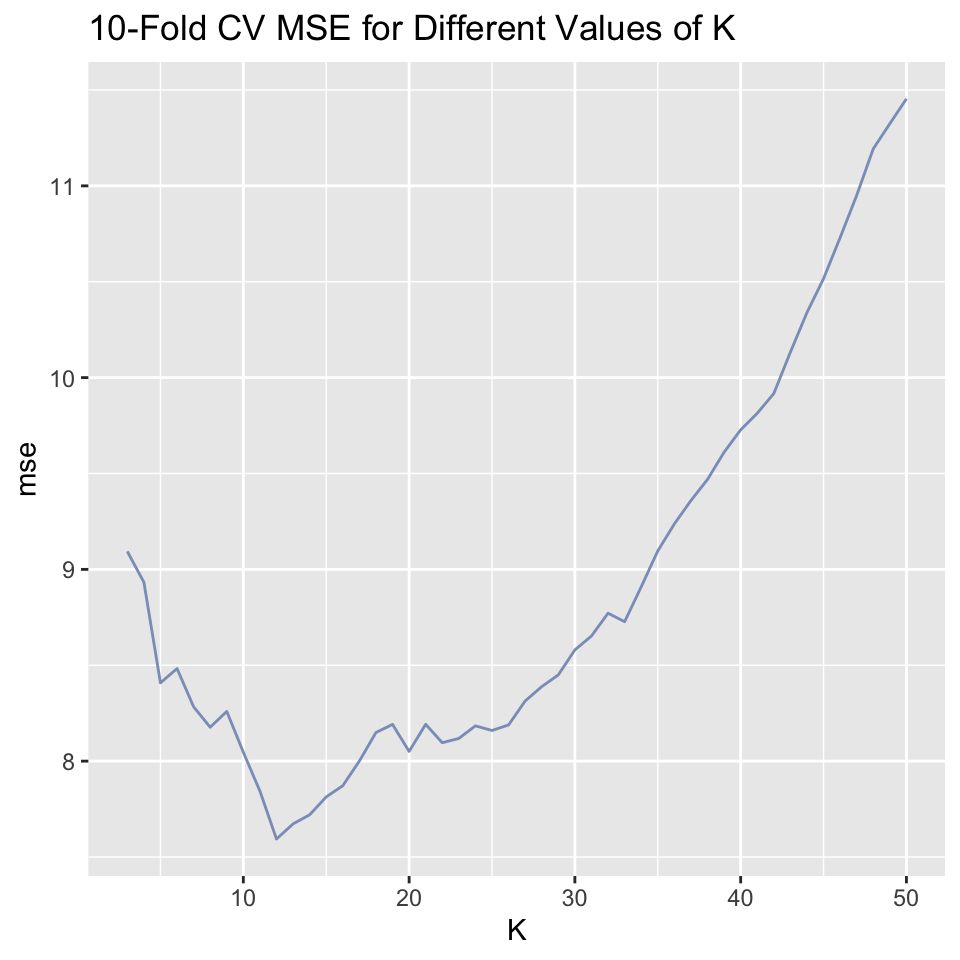

```r
ggplot(data = mse.comparison) + geom_line(mapping = aes(x = K, y = mse), colour = hcl(h = 250, l = 65)) + ggtitle("10-Fold CV MSE for Different Values of K")
```

2. The $k$ (number of neighbors) in a kNN model determines the effective degrees of freedom *edf*. What is the optimal *edf*? Be sure to use the correct sample size when making this calculation. Produce a plot similar to that from part *a*, but use *edf* (effective degrees of freedom) on the x-axis.

```r
print("Optimal EDF")
```

```
#> [1] "Optimal EDF"
```

```r
floor(90 / 12)
```

```
#> [1] 7
```

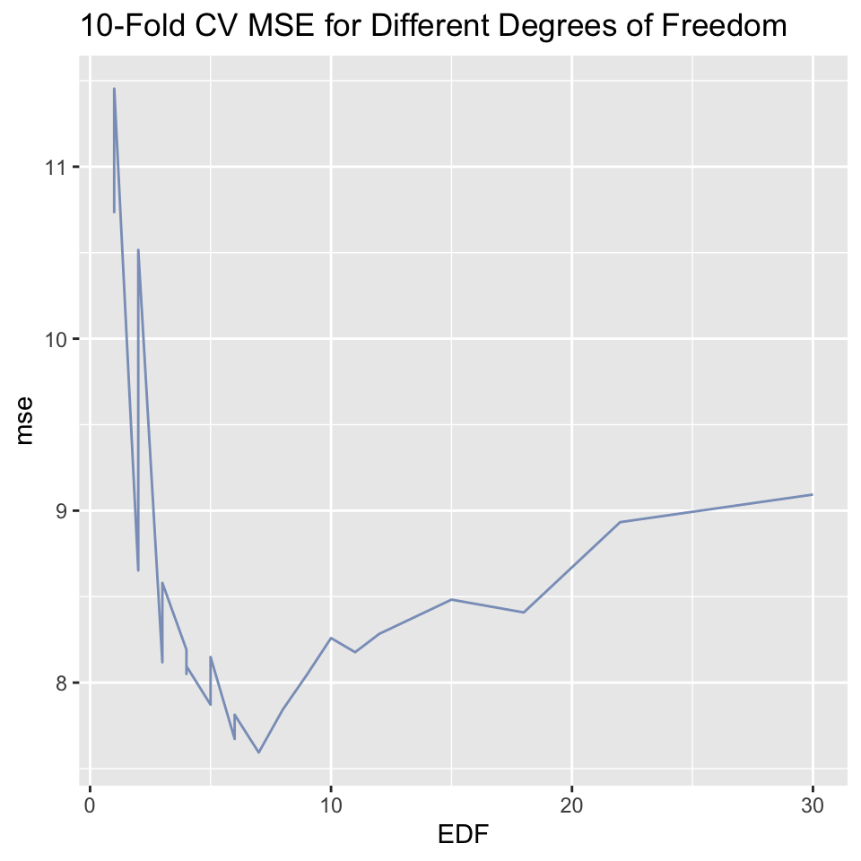

```r
mse.comparison <- mutate(mse.comparison, EDF = floor(90/K))
ggplot(data = mse.comparison) + geom_line(mapping = aes(x = EDF, y = mse), colour = hcl(h = 250, l = 65)) + ggtitle("10-Fold CV MSE for Different Degrees of Freedom")
```

3. After running cross-validation, a final model fit from *all* of the training data needs to be produced to make predictions. What value of $k$ would you choose? Why?

12 because that value minimized mean square error over 10-fold cross validation sets.

4. Now we will see how well cross-validation performed. Simulate a test data set of $50000$ observations from the same distributions. Use `set.seed(723)` prior to generating the test data.
   - Fit a set of kNN models, using the full training data, and calculate the mean squared error (MSE) on the test data for each model. Use the same $k$ values in *a*.
   - Report the optimal $k$, the corresponding *edf*, and MSE based on the test set.

```r
set.seed(723)
X.test <- X.Sample(50000)
e.test <- e(50000)
Y.test <- Y.Sample(X.test, e.test)

mse.comparison.true <- data.frame(K = seq(3,50), mse = rep(0,48))
for (k in 3:50) {
test <- X.test
train <- Simulation
knn.trial <- knn.reg(train = as.data.frame(train$x), test = as.data.frame(test), y = as.data.frame(train$y), k = k)
start <- end + 1

mse.comparison.true[k-2, 2] <- mean((Y.test - knn.trial$pred)^2)
}
mse.comparison.true <- mutate(mse.comparison.true, EDF = floor(100/K))
print("Optimal K and MSE")
```

```
#> [1] "Optimal K and MSE"
```

```r
filter(mse.comparison.true, mse == min(mse))
```

```
#>   K      mse EDF
#> 1 6 7.421506  16
```

5. Plot both the cross-validation estimated and true test error on the same plot. See Figure 5.6 in ISL (pg 182) as a guide.
   - Produce two plots: one with $k$ on the x-axis and one with *edf* on the x-axis.

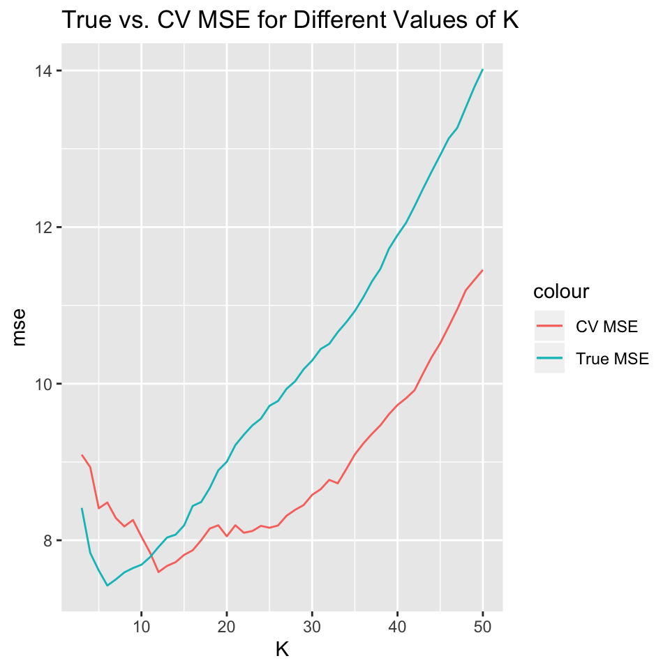

```r
ggplot(data = mse.comparison) + geom_line(mapping = aes(x = K, y = mse, colour = "CV MSE")) + geom_line(data = mse.comparison.true, mapping = aes(x = K, y = mse,colour = "True MSE")) + ggtitle("True vs. CV MSE for Different Values of K")
```

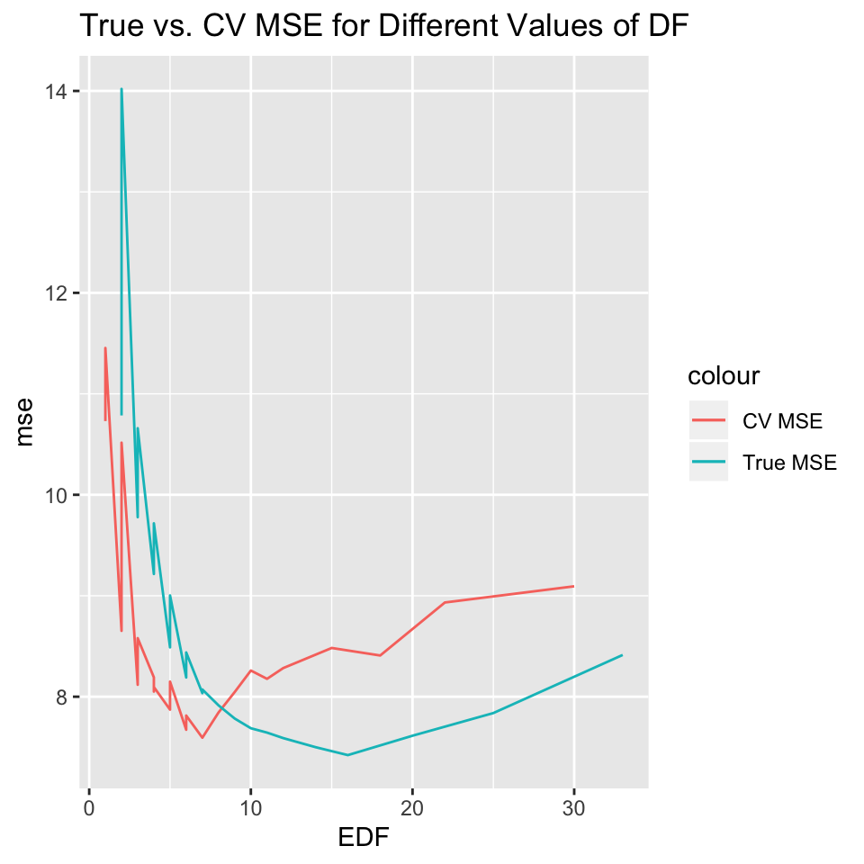

```r
ggplot(data = mse.comparison) + geom_line(mapping = aes(x = EDF, y = mse, colour = "CV MSE")) + geom_line(data = mse.comparison.true, mapping = aes(x = EDF, y = mse,colour = "True MSE")) + ggtitle("True vs. CV MSE for Different Values of DF")
```

6. Based on the plots from *e*, does it appear that cross-validation worked as intended? How sensitive is the choice of $k$ on the resulting test MSE?

Cross-validation overestimated the MSE for small values of K and underestimated it for large values of K. While it generated an optimal K of 12, while the true optimal K was 6, it only slightly underestimated the MSE at K = 12. In other words, using the cross-validated optimal k value would still generate a close-to-optimal estimate of the test data.

After k = 6, MSE icreases approximately linearly with increasing k.